# Media reactions to family Firms’ downsizing and upsizing decisions

Converted from PDF `Fourne-FamilyFirmMediaReactions-2025-JBR.pdf` · 12 pages · anchors: page `#pN`, block `#pN-bK`

Page 1

### Media reactions to family Firms’ downsizing and upsizing decisions<sup>☆</sup>

### Sebastian P.L. Fourn´e <sup>a</sup><sup>,</sup>*, Rico Kremer <sup>b</sup>, Miriam Zschoche <sup>c</sup>

a *University of North Florida, 1 UNF Drive, Jacksonville, FL 32224, United States of America* b *Signal Iduna, Neue Rabenstrasse 15019, 20354 Hamburg, Germany* c *University of Erfurt, Nordh*¨*auser Str. 63, 99089 Erfurt, Germany*

A R T I C L E I N F O

*Keywords:* Family firms Media coverage Employment restructuring Downsizing Upsizing Cognitive dissonance theory

A B S T R A C T

The media is an important stakeholder when firms announce restructuring decisions. We argue that journalists’ reactions vary depending on what is associated with family firms and non-family firms in terms of employment practices and whether it is a negative or a positive restructuring (downsizing vs. upsizing). Both types of restructuring may create a cognitive dissonance with the family firm image. Empirically, we analyze the media reactions to announcements of all major restructuring decisions of family firms and non-family firms based in Germany 2006–2019. The results confirm our hypothesis that family firms are evaluated on average more favorably when announcing a downsizing decision but elicit less favorable coverage of their upsizing decisions (than non-family firms). Our study highlights that, when being evaluated by media stakeholders, there are not only benefits when a firm is associated with specific (mostly positive) characteristics but that the same char acteristics can also be a burden in other situations.

#### **1. Introduction**

Media coverage is an authoritative source of information that confers legitimacy to organizations (Pollock & Rindova, 2003) and can sway stakeholders’ opinions (Deephouse, 2000; Hoffman & Ocasio, 2001). Scholars increasingly study how the media reports about firm behavior (e.g., Graf-Vlachy et al., 2020), yet only very few studies investigate media coverage of family firms. These studies explain how media coverage predicts family firms’ behavior (Sue et al., 2013), performance (Rovelli et al., 2022), or financial stakeholders’ reactions (Sanchez et al., 2024). Even though family firms are rather sensitive to media coverage (Gavana et al., 2017; Sanchez et al., 2024) because it may affect their reputation and legitimacy in the eyes of stakeholders, very little is known on whether and how family firms differ in their media coverage from non-family firms (Sageder et al., 2018). We strive to address this research void regarding media coverage of family firms’ behaviors by investigating media coverage of workforce restructuring (i.e., downsiz ing and upsizing) decisions of both family and non-family firms.

A downsizing is defined as a permanent major reduction in head count (Johnstone, 2024), whereas an upsizing is defined as a major

increase in headcount. Downsizing announcements tend to entail negative stakeholder reactions (Brauer and Vandepoele, 2023; Love & Kraatz, 2009), while for most external stakeholders upsizing decisions are a pleasant surprise and signal a positive outlook (Cascio et al., 2021). We study restructuring announcements because they are at odds with the image of family firms’ stability, continuity, and long-term orienta tion. More specifically, workforce restructuring is inconsistent with their higher job security, employment stability (Belling et al., 2022; Jau fenthaler, 2023; Rondi et al., 2022; van Essen et al., 2015), as well as more cautious hiring (relative to non-family firms) (Bassanini et al., 2013; Rivo-L´opez et al., 2022). In principle, neither downsizing nor upsizing is aligned with the family firm image. The main objective of this study is to investigate how being known as a family firm influences media reactions to upsizing and downsizing announcements (relative to how the media reacts to such restructuring announcements of non- family firms).

We draw on cognitive dissonance theory (Festinger, 1957; Hinojosa et al., 2017) and notions of deviating from the family firm image (Zellweger et al., 2012) to develop theory about why media stakeholders may react differently to restructuring decisions of family firms (vs. non-

☆This study was initiated while Dr. Sebastian Fourn´e was Associate Professor at Wilfrid Laurier University in Waterloo, Canada and was supported by SSHRC Insight Grant #435–2022-0687. The authors would like to thank the JoBR Editors Dr. Pesch and Dr. Heyden, two reviewers, Laura Bergmann, Ricarda Fourn´e- Aarden, Philip Kim, and Reddi Kotha for their advice and support in developing this study.

* Corresponding author. *E-mail addresses:* s.fourne@unf.edu (S.P.L. Fourn´e), kremer.rico@gmail.com (R. Kremer), miriam.zschoche@uni-erfurt.de (M. Zschoche).

Contents lists available at ScienceDirect

## Journal of Business Research

journal homepage: www.elsevier.com/locate/jbusres

https://doi.org/10.1016/j.jbusres.2025.115348 Received 9 April 2024; Received in revised form 28 March 2025; Accepted 28 March 2025

Journal of Business Research 193 (2025) 115348

Available online 2 April 2025 0148-2963/© 2025 Elsevier Inc. All rights are reserved, including those for text and data mining, AI training, and similar technologies.

Page 2

family firms). Cognitive dissonance theory may provide a suitable framework for understanding media evaluations of family firms compared to non-family firms since it can explain how journalists may react when a restructuring is announced, which is a disconfirmation of the family firm image. This disconfirmation is a discrepancy with prior cognitions of journalists, which according to the main premise of cognitive dissonance theory may lead to attempts to reduce the perceived discrepancy (Festinger, 1957; Hinojosa et al., 2017). Our ex planations address the question whether being known as a family firm entails benefits in terms of media coverage of restructuring decisions or if family firms may face disadvantages (relative to non-family firms) when making (seemingly) negative or positive restructuring decisions.

We test our theorizing by investigating print media reactions to all downsizing and upsizing announcements of family and non-family firms based in Germany for the 2006–2019 period with a differences-in- differences approach. We analyze 464 downsizing announcements with 15,913 corresponding media articles and 324 upsizing announce ments with 2,128 corresponding media articles, respectively, using an automated content analysis technique.

We contribute, first, to family firm research with a focus on how media stakeholders evaluate different restructuring decisions of family firms (relative to non-family firms). Given the importance of non- financial goals of family firms, this addresses an imbalance in family firm research, which tends to focus on performance outcomes (Amit & Villalonga, 2014; Chrisman et al., 2010) rather than non-economic outcomes tied to the other priorities of family firms (Holt et al., 2017). Studies of the representation of family firms in the media are scarce but recommended because of the importance of media coverage for firm behavior (Sageder et al., 2018) and as a social arbiter in firm–stakeholder relationships (Bednar et al., 2013; Deephouse, 2000; Pollock & Rindova, 2003). Positive media coverage can affect attaining economic as well as non-economic goals and may resonate positively with family firms’ stakeholders (Sanchez et al., 2024). By linking cognitive dissonance theory to family business research, we develop new theory about the consequences of being known as a family firm; spe cifically, about media coverage of restructurings that are (likely) at odds with the family firm image. For such ‘disconfirmations’ we consider both the potential benefits and downsides of being known as a family firm. Thereby, we challenge the common understanding that usually family firms’ image has positive consequences (Chaudhary et al., 2021; Sageder et al., 2018), explore situations in which it may reduce support of stakeholders (Zellweger et al., 2012), and extend insights into the op portunity costs that workforce restructurings may have especially for family firms (Belling et al., 2022).

Second, we extend research about restructuring by theorizing and testing differences in the media coverage for different types of firms. Previous studies tend to focus on downsizings, documenting usually negative investor reactions (Brauer and Vandepoele, 2023). Others show a (negative) impact on firm reputation (Love & Kraatz, 2009; Schulz & Johann, 2018) or increases in uncertainty and deterioration of cus tomer’s trust (Homburg et al., 2012). We are among the first to focus on media coverage – an increasingly important outcome – and to examine reactions to both workforce downsizing and upsizing. Doing so, we can reveal what otherwise would be hidden: being known as a family firm can have different (beneficial and burdensome) effects for this type of organization in terms of media stakeholder reactions.

#### **2. Theory and hypothesis**

Media coverage has important consequences for all types of organi zations as it affects their reputation and legitimacy in the eyes of mul tiple stakeholders (Bansal & Clelland, 2004; Deephouse, 1996; Kennedy, 2008) and can cause firms to make major strategic changes (Bednar et al., 2013). Media agents are “propagators of legitimacy” (Pollock & Rindova, 2003, p. 632) who can direct the attention of external stake holders to issues a firm faces or caused (Bednar et al., 2013).

Stakeholders deem media-disseminated information as credible (Pollock & Rindova, 2003) and use it to judge firm behavior (Zavyalova et al., 2012). Whether journalists frame organizations’ behaviors in a positive or negative light has important consequences for stakeholders’ impres sions (Westphal & Deephouse, 2011). Positive media coverage may improve firms’ performance (Deephouse, 2000). Conversely, negative press coverage can negatively affect stakeholders’ perceptions of the firm, harm its reputation, and lead to stigmatization of the firm (Wiesenfeld et al., 2008). In turn, this may have negative performance consequences.

Generally, large publicly listed firms are more visible in media coverage than (most) family firms, which makes the rare coverage of family firms even more newsworthy and important in terms of what meets the public eye (Jonkman et al., 2020). The reporting about firms that are only rarely covered may have a stronger impact on these firms (Bednar et al., 2013). Media coverage can come with reputational risks, which may also be tied to social capital of the firm and other non- economic goals, which family firms do not wish to jeopardize. Family firms’ owners like control over the reputation of their firm and how the family name is seen in public. That said, media reactions are difficult to control, and it matters to be able to anticipate what members of the media expect (based on their prior cognitions) and how they may react to a family firms’ strategic decisions. If the media coverage of family firms is favorable, not only the chances of economic success (Pfarrer et al., 2010) but also of achieving non-economic goals (such as devel oping reputational assets and augmenting social capital) may improve (Arregle et al., 2007). This in turn may have lasting benefits for family firms (Ciravegna et al., 2020).

Next, we draw on cognitive dissonance theory (Festinger, 1957; Hinojosa et al., 2017) to develop theory about media stakeholders’ re actions to different restructuring decisions (relative to similar decisions of non-family firms), explaining when the employment and recruitment characteristics family firms are renown for may be beneficial or burdensome in the restructuring context. Cognitive dissonance theory has a long tradition of explaining psychological discomfort arising from inconsistencies of different cognitions, which lead to feelings of un pleasantness (Festinger, 1957; Hinojosa et al., 2017). To reduce this unpleasantness and restore cognitive consistency, actors usually resort to discrepancy reduction and may suppress cognitions that serve as a disconfirmation especially of rather enduring cognitions (Harmon-Jones et al., 2009). Dissonant elements could be organizations’ wrongdoing or misconduct – inconsistent with morally sound practices (Jedicke et al., 2025; Kim & Krishna, 2022) or journalists dealing with news of poor performance of firms whose leadership they hold in high esteem (Westphal & Deephouse, 2011).

In the latter context, cognitive dissonance theory predicts that “ac tors who.

have received tangible or intangible favors from another are likely to feel cognitive dissonance, or even self-reproach and guilt, from taking actions that harm the interests of their benefactor (Westphal & Deep house, 2011, p. 1046). As such, ingratiatory behavior of CEOs is recip rocated by journalists even when expectations are not met (i.e., a firm performs below consensus forecasts). Because of otherwise experiencing cognitive dissonance, journalists are reluctant to issue negative state ments about the CEO or firm (Westphal & Deephouse, 2011). Recipro cating positive attitudes or affect towards each other affects the processing of negative information and can lead to “external attributions for disappointing performance outcomes” (Westphal & Deephouse, 2011, p. 1067). Related research explains that when a cognitive dissonance arises due to a psychological breach, stakeholders who trust a firm may focus on information that portrays the firm as fair and the breach as beyond its control (Dulac et al., 2008). When stakeholders perceive two or more cognitions which are contradictory, “they will feel an unpleasant state—dissonance—until they are able to resolve this state by altering their cognitions (Hinojosa et al., 2017, p. 171).”.

2

Page 3

Cognitions which stakeholders hold of a firm are receiver-based, reflecting the perspective and assessment of an (external) observer. Cognitions of stakeholders are often based on firms’ image, especially, what firms stand for, commonly value, or are valued for, and what they share with the public or directly with the media (Westphal & Deephouse, 2011; Zavyalova et al., 2012). Cognitions of a firm’s image develop through absorption of first-hand information as well as social narratives. Importantly, family firms have a unique image that can serve as a competitive advantage (Astrachan et al., 2018; Zellweger et al., 2012). The family firm image can elicit favorable attitudes of consumers (Beck & Prügl, 2018), who value family firms for trustworthiness and consis tency. It has also been related to consumer forgiveness for family firm wrongdoing (Datta & Mukherjee, 2002).

Stakeholders’ associations with the family firm image include attri butes such as their tradition (passed on over generations) (Erdogan et al., 2020), long-term orientation (Zellweger, 2007), or regional focus and embeddedness alongside cautious international growth (Fourn´e et al., 2023; Fourn´e & Zschoche, 2020). There is also higher social cohesion, trust, and commitment among employees of family firms, which stems from superior bonding social capital (relative to non-family firms) (Herrero, 2018). These associations with the family firm image may play a role for stakeholders who evaluate family firms’ behaviors (in an employment context). Customarily, the positive associations with the family firm image outweigh the negative ones (e.g., associations with nepotism or lack of professionalism) (Datta & Mukherjee, 2022; Sageder et al., 2018; Zellweger et al., 2012).

*2.1. Journalists’ cognitions of family firms’ recruitment and employment*

Most relevant to our context and consistent with family firms’ longterm orientation and stability, family firms are more cautious when hiring in good times and more reluctant to lay off employees than non- family firms (Bassanini et al., 2013; Rivo-L´opez et al., 2022; van Essen et al., 2015). As family firms focus on “attracting local employees seeking stability and retaining them for decades” (Rondi et al., 2022, p.1), their characteristics include greater job security than non-family firms’ job security (Jaufenthaler, 2023; Neckebrouck et al., 2018). Several studies have shown that family firms are less likely to downsize than non-family firms (Sanchez-Bueno et al., 2020), especially in times of (macroeconomic) crisis (Amato et al., 2023; van Essen et al., 2015) or when the business is in decline (Belling et al., 2022). Family firms’ multi-generational outlook generates a longer time horizon than in non- family firms (James 1999; Zellweger, 2007). Therefore, family firms can more credibly commit to long-term contracts (Anderson & Reeb, 2003) and tend to benefit from long-term employment.

In terms of employment characteristics, research suggests that family firms differ not only in positive ways from non-family firms (as the above suggests). Some studies present a more negative picture sug gesting that family firms pay lower wages (Bassanini et al., 2013; Neckebrouck et al., 2018), invest less in employee training, have slightly higher voluntary turnover (Neckebrouck et al., 2018), sometimes rely on unfair compensation systems (Chua et al., 2009), use of lower peer appraisal processes (Fiegener et al., 1994), and exhibit weaker internal social performance (Cruz et al., 2014). That said, even the studies crit ical about family firms’ employment practices show in robustness ana lyses (Neckebrouck et al., 2018) or in their main findings (Bassanini et al., 2013) that family firms’ have lower dismissal rates and higher job security. Notably, given their unique resources and goals, family firms have a higher threshold of decline (than non-family firms) to engage in a downsizing (Belling et al., 2022). There is no study (to our knowledge) showing that family firms offer lower job security or shorter-term employment relative to non-family firms.

Furthermore, major media outlets do present findings of annual surveys about the public perception of family and non-family firms, suggesting that the former have a more positive reputation because of their fairness towards their employees and long-term orientation

(Frankfurter Allgemeine Zeitung, 2024). This shows journalists’ awareness of family firms’ image. Based on the above, one can anticipate that in this context journalists’ cognitions of family firms may differ from their cognitions of non-family firms.

In accordance with cognitive dissonance theory, when stakeholders such as journalists evaluate family firms’ decisions that are inconsistent with their perception of family firm image, they will seek ways to “reduce dissonance by engaging in discrepancy reduction […] or adjusting the importance of the cognitions” (Hinojosa et al., 2017, p. 173). Journalists may employ a mix of removing or reducing the importance of new, discrepant cognitions, or raising the importance of more consonant cognitions – all of which are ways to reduce cognitive dissonance (Harmon-Jones & Mills, 2009). For instance, trivialization or suppression of disconfirmatory cognitions may occur when the original perception is resistant to change. To cope with disconfirmation of the family firm image of stability, continuity, long-term orientation, and employment characteristics (such as job security), selective information processing may occur to support these prior (and likely lasting) cogni tions (often nurtured by family firms over decades). Attempts to reduce cognitive dissonance can lead journalists to cover restructurings of family firms differently than non-family firms’ restructurings. Achieving expectation fit is an attempt to support the commonly perceived image of the family firm (Russo et al., 1996).

*2.2. Downsizing and Upsizing: A disconfirmation of the family firm image*

Organizations’ workforce restructurings (i.e., downsizing or upsiz ing) are rarely occurring, high-impact strategic decisions. A downsizing, defined as a permanent major reduction in headcount (Johnstone, 2024), is a sign of uncertainty (Cascio et al., 2021) and incurs direct and indirect costs (Brauer and Vandepoele, 2023). For instance, downsizing breaks commitments to and the implicit ‘psychological contract’ with employees (Love & Kraatz, 2009; Mishra & Mishra, 1994; Morrison & Robinson, 1997). The morale as well as the productivity of the remaining employees often deteriorate following a downsizing announcement (Iverson & Zatzick, 2011). A downsizing can be inter preted as a betrayal of employees and signals reduced growth prospects (at least in currently served markets). In contrast, an upsizing is defined as a major increase in the workforce and announcements of such mass hirings are usually positive news and signal growth prospects (Cascio et al., 2021). An upsizing could also be a necessary step to develop new organizational capabilities. An upsizing is more likely to occur when a firm is performing well and investments in human capital are possible (Titus et al., 2022). Upsizing reflects a positive management outlook with confidence in the firm’s strategic choices by investing in human (and possibly in combination also physical) resources (Cascio et al., 2021). Given journalists’ image of family firms and their approach to recruitment and employment, downsizing decisions of family firms are more surprising than similar restructurings of non-family firms (that may have lower thresholds to engage in a downsizing (Belling et al., 2022)). Journalists focusing on media coverage of workforce restruc turing may pay attention to how these restructurings are inconsistent with the usual long-term employment, high job security, or cautious hiring of family firms. This causes a cognitive dissonance with prior cognitions of family firms’ as only very rarely (if at all) going through any kind of restructuring.

When family firms engage in workforce downsizing, they may benefit from a buffer in terms of goodwill and forgiveness as journalists attempt to reduce the cognitive dissonance. With their (usual) commitment toward employees (e.g., Neckebrouck et al., 2018), their inclination even in more dire times to maintain employment as long as possible (Bassanini et al., 2013), and their social capital in the business community (e.g., Ciravegna et al., 2020), family firms have accumulated a ‘reservoir of goodwill’ among external stakeholders (that exceeds the goodwill of non-family firms). This goodwill can elicit more positive

3

Page 4

affective responses to family firms’ adverse choices (than non-family firms’) as journalists will tend to suppress the negative disconfirma tion of the traditionally favorable family firm image. This is beneficial for family firms that downsize because it may sway journalists to focus on prior cognitions and report more favorably about family firms’ downsizing than for non-family firms.

In addition, a lasting positive image of family firms can alleviate the impacts of a challenging decision or situation and may prompt media stakeholders to give them the ‘benefit of the doubt’ (Coombs & Holla day, 2006; Park & Rogan, 2019) as evaluators strive to reduce cognitive dissonance and are reluctant to adjust initial cognitions even when presented with disconfirming evidence (Traut-Mattausch et al., 2004). For instance, in the context of negative earnings surprises, Pfarrer et al. (2010) argue that firm reputation and celebrity can make evaluators beliefs more resilient to negative information and less likely to attribute it directly to the firm. We posit that to reduce cognitive dissonance of a downsizing with the family firm image, journalists may externalize the blame. Thereby, they avoid changing prior impressions of the family firm. Given the reluctance of family firms to engage in major layoffs, it is often an ‘action of last resort’ (Bassanini et al., 2013; van Essen et al., 2015) and demands a higher decline threshold (than non-family firms’ downsizing) (Belling et al., 2022). As such, journalists may process in formation selectively, trusting that a family firm’s downsizing was un avoidable (a reduction of cognitive dissonance that limits the room for negative interpretation). Journalists are likely familiar with family firms’ long-term orientation and the desire to prepare the firm for the next generation, and thus, they may see a downsizing as an unavoidable deviation from a long-term plan. This rationale may be mentioned in the announcement and journalists are more likely to pick up on the notion of an ‘action of last resort’ for family firms (than for non-family firms). Instead of blaming the family firm for a downsizing, media stakeholders may exercise more mild judgment and attribute this exceptional event to circumstances beyond the family firms’ control such as industry or macro-economic factors (e.g., Busenbark et al., 2019).

In summary, journalists working on downsizing media coverage and seeking consistency with the family firm image are more likely to label this kind of restructuring as a necessity and important for family firms’ recovery. Family firms “understand the importance of goodwill and social capital derived from their communities and therefore these firms make a concerted effort to build a positive family firm image” which helps them through loyalty and trust of stakeholders including jour nalists when it is needed most (Zellweger, 2012, p. 243). Trust leads to forgiveness as stakeholders “minimize the attribution of blame to a [family] firm” and “strengthen the presumption of innocence about the family firm” (Datta & Mukherjee, 2022, p. 260), which may be reflected in more mild media coverage. Hence, we expect a benefit from being known as a family firm when announcing a downsizing and that unfa vorable parts of downsizing media coverage may be rather muted for family firms.

In contrast, in an upsizing, deviation from the family firm image of stability, continuity, and cautious hiring may also cause a cognitive dissonance – that, if reduced by journalists, who suppress discrepant information that is particularly favorable but not aligned with prior cognitions (e.g., speed of expansion), may lead to less favorably coverage by the media than for non-family firms.

First, for non-family firms upsizing can be attributed to realizing their growth ambitions and it does reinforce positive beliefs about the potential of the non-family firm. Such a bold move will be more likely to be interpreted as a ‘bold and ‘bullish’ signal for non-family as it creates less of a cognitive dissonance than when it is a family firm announcing an upsizing. Media coverage of family firms’ upsizing may be less favorable than for non-family firms because an upsizing is inconsistent with key characteristics of family firms. The rationale for an upsizing can in (in most instances) not be externalized to outside pressures or that it was unavoidable. It is a decision of the firm and its leaders – and in the case of family firms it may appear inconsistent with some of the

hallmarks, such as continuity and stability, of family firms.

Second, while an upsizing is regarded overall as rather favorable since it signals growth and is likely supported by strong past perfor mance, we expect that family firms’ upsizings create cognitive disso nances when explaining the upsizing rationale against the characteristics of family firms. Given their employment stability over decades (Jaufenthaler, 2023; van Essen et al., 2015) and longer planning horizons (Zellweger, 2007), family firms face higher expectations of stability and sustainability of their choices. An upsizing may increase business risks in the long run, in bursts of growth lies a risk of a decline in reliability, which in turn may lead to questions about future job se curity (Bassanini et al., 2013). Also, family firms are known for cautious hiring and slow socialization of their employees, developing deeper social relations inside the firm, which is challenging if adding hundreds or even thousands of new employees in a short period of time. There may be uncertainty in the eyes of journalists if family firms can manage major growth bursts and a cognitive dissonance with long-term orientation and planning horizons which would suggest steady growth and no unex pected major hiring efforts. Accordingly, journalists’ reduction of the cognitive dissonance may mean suppressing very positive information to restore cognitive consistency with the stable image of family firms.

Third, journalists’ cognitions may also be shaped by what employ ment in family firms is renowned for as per family firms’ goals and values. Trusting and cooperative relationships between the family and employees are among these values (Beck & Prügl, 2018). Internal social capital is (often) superior in family firms and relies on enduring coop eration (Arregle et al., 2007; Pittino et al., 2016). Accordingly, jour nalists may see higher opportunity costs for family firms than non-family firms when evaluating their upsizing decisions as these trusting and cooperative relationships (and other aspects of their internal social capital) may be disrupted by too many newcomers.

Finally, family firms are often known for their humility rhetoric – that aligns with their image (Dyer & Whetten, 2006; Sanchez et al., 2024). An upsizing may appear inconsistent with prior humble communication and the down-to-earth nature of family firms, thus sending mixed signals to media stakeholders. These mixed signals could lead to less favorable reporting than for non-family firms as prior cog nitions, which may be attributed higher importance to reduce cognitive dissonance (Harmon-Jones & Mills, 2009), guide journalists towards more muted and humble reporting than prior cognitions of non-family firms do. Hence, in sum we expect that:

*Hypothesis: In a downsizing situation the media coverage of family firms is more favorable (than of non-family firms), whereas in an upsizing situation the media coverage of family firms is less favorable (than of non-family firms).*

#### **3. Methods**

*3.1. Sample*

Our sample includes all restructuring announcements made by firms based in Germany for the period 2006–2019. Within this time frame 645 downsizing announcements occurred (targeting at least 100 employees). From this initial sample, we eliminated all bankruptcies and ‘acquisi tion-related downsizing events’ because they are conducted with different motives (O’Shaughnessy and Flanagan, 1998). Further, we had to exclude observations with missing data regarding media coverage, financial control variables, and/or ownership characteristics. As a result, we receive 464 downsizing observations with corresponding media coverage. On average, firms announced a dismissal of 1,278 employees per event (or 7.2 % of employees dismissed in relation to the overall workforce of the focal firm in Germany). Consistent with existing studies this indicates large-scale firm restructuring (Cascio et al., 2021).

Analogously, we identified 635 upsizings between 2006 and 2019, which targeted at least 100 employees. Only 61 % of those

4

Page 5

announcements received media coverage. Excluding observation with missing information on firm characteristics, we end up with of 324 upsizing announcements (with media coverage) with an average of 1,629 employees added per event (or 8.5 % of employees added in relation to the overall workforce in Germany). Our final sample consists of 788 restructuring events with corresponding media coverage, of which 464 are downsizings and 324 are upsizings.

Our sample comprises restructuring decisions only that are classified as downsizings or upsizings, made by firms that are either considered as family firms or non-family firms. That means, when measuring the media coverage of upsizings, it is compared against the media coverage of downsizings. When measuring the media coverage of family firms, it is compared against the media coverage of non-family firms. In our analysis, we are interested in the relative differences between the two kinds of restructuring decisions for the two kinds of firms (differences- in-differences approach) (e.g., Amore et al., 2021; Fourn´e et al., 2023).

In order to capture media reactions, we collected all media articles published in the 20 largest German newspapers by circulation (i.e., 8 national and 12 regional daily newspapers) related to the restructuring announcement of the focal firm in the year it announced the decision (e. g., Bednar et al., 2013; Titus et al., 2018). To identify articles for our time window, we utilized Lexis-Nexis database, Genios database, and the newspapers’ archives. To filter relevant media articles, we employed German synonyms for the words ‘downsizing’ and ‘upsizing’ (Heinz & Swinnen, 2015). We manually reviewed all articles and removed any article not directly reporting about the focal company and the restruc turing decision. Consistent with prior research, we also removed any duplicate articles and any articles that were an exact reprint of a com pany’s press release (Gamache & McNamara, 2019; Titus et al., 2018). Based on this data collecting approach, we were able to obtain 15,913 media articles explicitly covering the downsizing instances we sampled (on average, 34.3 articles per downsizing) and 2,128 media articles explicitly covering the upsizing decisions (on average, 6.6 articles per upsizing).

*3.2. Variables*

**Dependent Variable.** To capture the *media tenor*, we followed these steps: (1) We analyzed the content of each article by using the German version of the Linguistic Inquiry and Word Count (DE-LIWC) 2015 software (Meier et al., 2019). LIWC is a word counting software with built-in dictionaries that contains pre-designed and pre-validated words analyzing the positive and negative emotion (valence) of a text passage (Pennebaker & Chung, 2007). Many studies have employed LIWC to measure media content (e.g., Bednar, 2012; Gamache & McNamara, 2019; Shipilov et al., 2019). Based on this content analysis and in line with previous research, we then (2) coded each article as positive if its total affective content was at least 60 % positive and as negative if its total affective content was at least 60 % negative (Zavyalova et al., 2012). Although this is a common approach, one ‘bias’ that may arise from coding the affective content of entire articles through LIWC is a distortion due to multiple mentions of firms in the article. It might be possible that the affective content of the article is negative, but the overall assertion of the focal firm is positive (Zavyalova et al., 2012). To ensure reliable coding of media coverage of firms’ restructuring an nouncements through LIWC and to follow established practices in con tent analysis, we randomly selected 50 articles and recoded them (Bednar et al., 2013; Desai, 2011; Pollock et al., 2008). One student assistant, who was unaware of the empirical set-up, reread the articles and highlighted discrepancies between the tenor of an entire article and the tenor of coverage of a specific firm. We found no systematic differ ences to results from LIWC. In the final step (3), we measured media tenor of the focal firms’ downsizing and upsizing announcements by employing the Janis-Fader coefficient of imbalance (for details please see Deephouse, 2000). The range of this continuous variable is −1 to 1, where −1 equals ‘all negative coverage’ and 1 equals ‘all positive

coverage’.

**Independent variables.** Typically, family firm status is defined by the two components ownership and involvement (Gomez-Mejia et al., 2010). The family firm literature suggests different minimum ownership stakes, starting from 5 % (Gomez-Mejia et al., 2010) up to 50 % (Fourn´e et al., 2023). Involvement can be exerted by family member participa tion within the Board, the Top Management Team (TMT), or by leading the firm activities as Chief Executive Officer (CEO) (Feldman et al., 2016). We follow existing literature and define the dichotomous vari able *family firm* as ‘1′ (‘0′ otherwise) if (a) the founder or members of his family by blood or marriage own a firm with at least 10 % ownership, either individually or as a group and (b) the founder or members of his family are part of the firm’s Board (Fan & Leung, 2020; Graves & Thomas, 2008; Sanchez-Bueno & Usero, 2014). In robustness checks, we vary the ownership thresholds and the type of involvement (on the Board or TMT), leading to very similar results. *Upsizing* equals ‘1′ if the restructuring event is an upsizing and ‘0′ if it is a downsizing.

**Control Variables.** Several additional factors can determine the media coverage of restructuring announcements. Therefore, we control for antecedents of media coverage identified in prior studies. All data for the control variables was retrieved from the Amadeus Database, Reuters Knowledge Direct, and/ or from firms’ annual reports.

We control for *firm size* as the log number of employees in the focal year and *net profit margin* of a firm as the financial situation of a firm influences the degree of attention given to a firm (Pollock & Rindova, 2003). Furthermore, *media visibility* may affect the general salience of a firm, and thus could influence media agents assessment of a firm’s de cision (e.g., Bednar et al., 2013; Gamache & McNamara, 2019; Zavya lova et al., 2012). We measure prior media visibility as the total articles a firm received one year prior to the focal firm restructuring announcement. Similarly, prior firm behavior may affect journalists’ cognition and attention to the focal event (e.g., K¨onig et al., 2018). To control for an underlying corporate scandal that could dominate media coverage, we created a variable that addresses whether the sampled firm faced a scandal (for instance, a product recall, management misbe havior, or bribery) one year prior to the focal firm’s restructuring announcement (“1″ if yes, “0” otherwise). We did so by searching in LexisNexis with the German word for ‘scandal’ in combination with the respective firm (e.g., Bednar, 2012). We further control for the *number of articles* a restructuring announcement received in total. A higher ‘num ber’ points to a higher attention by media stakeholders toward the restructuring decision. Finally, we include year and industry dummies.

#### **4. Results**

Table 1 depicts the variables’ means, standard deviations, and pairwise correlations. We also calculated the variance inflation factors (VIF), which are all close to 1 (mean VIF = 1.21). Thus, we do not detect any serious multicollinearity problems.

When looking at the descriptive statistics, we see that the media tenor is positive throughout the sample (*m* = 0.37, see Table 1). Upsizing announcements receive on average more favorable media coverage (*m* = 0.60) than downsizing announcements (for both types of firms). Media coverage of downsizings is still positive on average (*m* = 0.21). The difference is significant (*p* = 0.000) according to a two-tailed *t*-test. Further, across both types of restructuring announcements there is no significant difference in media coverage of family firms (*m* = 0.36) compared to non-family firms (*m* = 0.37). Fig. 1 depicts these mean values of media tenor for family firms and non-family firms in down sizing and upsizing situations.

To test our hypothesis, we first provide basic differences-indifferences analyses for the two types of firms (Amore et al., 2021). We conducted t-tests to investigate whether the differences of the mean values of media tenor following downsizing and upsizing announce ments for family firms and non-family firms (see Fig. 1) are significant. Table 2 shows that upsizing is evaluated significantly more favorably

5

Page 6

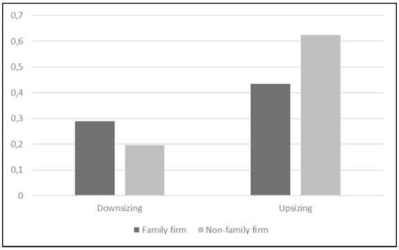

NOTE: figure/graphic rendered as an image from the PDF; its content is not machine-readable text. Caption (if any) follows as the next block.

(compared to downsizing) for both family firms (*d* = 0.145, *p* = 0.028) and non-family firms (*d* = 0.430, *p* = 0.000). When announcing a downsizing decision, there is weak empirical support that family firms receive more positive media evaluation than non-family firms (*d* = 0.093, *p* = 0.063); when it comes to upsizing, family firms receive a significantly less positive media evaluation than non-family firms (*d* = -0.192, *p* = 0.002). This lends first support for our *Hypothesis.*

As a second step, we conducted multivariate regression analyses, which allows us to control for additional influences, which might affect the media evaluations of restructuring decisions. As some firms announced downsizing and upsizing events in the same year, there are repeated time values in the sample, which does not allow to employ a longitudinal panel regression. Instead, we employ a pooled panel regression. Table 3 reports the results of pooled OLS regression with robust standard errors. Model 1 in Table 3 contains just the control variables; in Model 2 the independent variables are included. The co efficient of *upsizing* is positive and significant (*β* = 0.365, *p* = 0.000); the

coefficient of *family firm* is insignificant (*β* = -0.003, *p* = 0.946). In Model 3, we add the interaction term of *family firm* and *upsizing*; its coefficient is negative and significant (*β* = -0.254, *p* = 0.002), suggesting

**Table 1** Descriptive statistics and pairwise correlations.

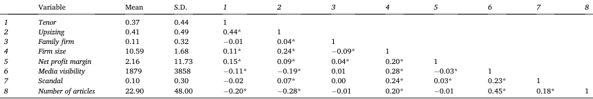

NOTE: complex table shown as an image of the PDF; the text below is a rough machine extraction and may be mis-aligned.

Note: n = 788; S.D. = standard deviation; *p *<* 0.05.

**Fig. 1.** Mean values of media tenor of family firms and non-family firms for both restructuring types.

**Table 2** Differences in media tenor.

[output not shown]

NOTE: table converted from PDF layout to HTML text; cell boundaries are reconstructed. See PDF if exact alignment matters.

Note: This table provides *t*-test comparisons of the average media tenor for family firms and non-family firms when announcing a downsizing or upsizing decision. **p *<* 0.01, *p *<* 0.05, †p *<* 0.1; n = 788.

**Table 3** Regression results.

[output not shown]

NOTE: table converted from PDF layout to HTML text; cell boundaries are reconstructed. See PDF if exact alignment matters.

Note: Standard errors in parentheses; **p *<* 0.01, *p *<* 0.05, †p *<* 0.1; no. of observations: 788.

6

Page 7

that family firms receive less favorable media coverage when announcing an upsizing. Importantly, given the nature of our empirical design, the downsizing coefficient and its interaction with the family firm variable are the inverse of the upsizing treatment (not reported; see a similar differences-in-differences approach in Fourn´e et al., 2023) pointing to family firms receiving more favorable media coverage of their downsizings than non-family firms. Thus, regression analysis provides further support for our *Hypothesis*. Fig. 2 depicts the interaction effect graphically, showing how media coverage differs for family firms’ relative to non-family firms’ restructuring decisions.

*4.1. Robustness analyses*

We conducted several robustness analyses to substantiate our find ings. First, we varied the definition of being a family firm by using different minimum ownership stakes and a different type of family involvement. In Model 1 of Table 4, *family firm* is defined with a mini mum of 25 % family ownership share and Board membership. In Model 2 (Table 4), *family firm* is defined with a minimum of 50 % family ownership share and Board membership. In Model 3 (Table 4), *family firm* is defined with a minimum of 10 % family ownership share and family member TMT membership. All variations delivered very similar results as in the main regression (Table 3).

To be sure that journalists actually consider the family firm image and notice the ‘family-ness’ of family-owned firms, we further measured *family firm* with a dummy that captures all family firms that bear the family name (or a part) of the founder’s name or of a member of the founding family as the company name (Kashmiri & Mahajan, 2014). This robustness check (see Model 4 in Table 4) also delivers very similar results as compared to the main regression*.*

Further, time constraints may cause journalists to rely on other published articles when writing their own news articles (e.g., Hayward et al., 2004; Rindova et al., 2006). To account for this, we employed latent semantic similarity (LSS) analysis of media articles capturing each focal firm’s restructuring announcement. LSS is a computational method from linguistic research that allows to analyze how similar two or more text sources are (Babcock et al., 2014). To perform the computation, we employed the Basis Unit Transposable Text Experimentation Resource (‘BUTTER’ Version 0.9.4.1) and uploaded a pre-trained text corpus

focusing the German language (K¨oper & Im Walde, 2016) into the software. The final output from BUTTER for the LSS analysis ranges from −1 to + 1, where positive values indicate strong semantic similarity and negative values low semantic similarity. The LSS score is *m* = -0.161 in our sample. The result indicates no signs of strong language similarity among the media articles.

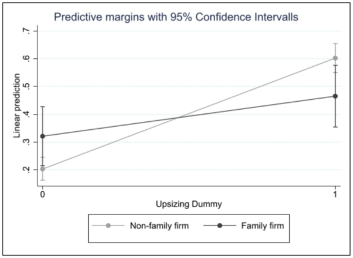

NOTE: figure/graphic rendered as an image from the PDF; its content is not machine-readable text. Caption (if any) follows as the next block.

**Fig. 2.** Interaction effect: family firm * upsizing.

**Table 4** Robustness checks with alternatives measures of family firm status.

[output not shown]

NOTE: table converted from PDF layout to HTML text; cell boundaries are reconstructed. See PDF if exact alignment matters.

Note: Standard errors in parentheses; **p *<* 0.01, *p *<* 0.05, †p *<* 0.1; In Model 1 family firm is defined with a 25 % family ownership share and family board membership. In Model 2 family firm is defined with a 50 % family ownership share and family board membership. In Model 3 family firm is defined with a 10 % family ownership share and family top management team membership. In Model 4 family firm is defined when a family firm has the family name in its firm name.

7

Page 8

#### **5. Discussion**

This study examines media stakeholders’ reactions to restructuring announcements of family and non-family firms. Despite the importance of non-economic goals of family firms, family firm research tends to focus on performance, innovation, or internationalization outcomes rather than a broader array of outcomes (Amit & Villalonga, 2014; Chrisman et al., 2010). As such, “research may not be fully capturing the desired and wide-ranging outcomes derived from the strategic priorities of family firms” (Holt et al., 2017, p. 183). Media coverage of family firms is among these outcomes. As recommended, we add to the so far scarce body of research on whether and how family firms differ in their media coverage from non-family firms (Sageder et al., 2018). Specif ically, we try to develop a better understanding of how deviating from the family firm image (here in the recruitment and employment context) is covered by media stakeholders. We find support for our hypothesis that in downsizing situations media coverage is more favorable for family firms (than for non-family firms), whereas it is less favorable for family firms (than for non-family firms) in upsizing situations.

Prior restructuring studies (with few exceptions) tend to focus on downsizings and on one type of organization (Cascio et al., 2021). By examining both types of workforce restructurings, we seek to advance family firm and restructuring research by explaining the differences in media stakeholders’ evaluation of family and non-family firms’ restructuring. Overall, there is no consistent evidence for family firms receiving significantly different media coverage than non-family firms when announcing restructurings. However, results for the different types of restructurings provide more insights and reveal when being (known as) a family firm can be of benefit or a burden.

*5.1. Media coverage of restructuring announcements*

Restructuring decisions are major strategic decisions (Bergh & Lawless, 1998; Bergh & Lim, 2008), which have been studied predom inantly in the context of publicly listed firms and the reaction of finan cial market participants (*cf*. Brauer and Vandepoele, 2023). However, most firms are not publicly listed ones and the importance of family firms’ growth for many economies’ GDP and employment has been emphasized consistently (Anderson & Reeb, 2004; Colli et al., 2013; De Massis et al., 2018; King et al., 2022). In addition, also non-financial stakeholders have a keen interest in restructuring decisions. Finally, there is a “paucity in the literature on employee upsizing” (Cascio et al., 2021, p. 588). We address these three overlooked aspects about firms’ restructuring and are among the first to examine non-financial stake holders’ reactions to both downsizing and upsizing decisions and do so for both family firms and non-family firms. Thereby, we generate new insights into media stakeholders’ reactions to different restructuring decisions (King et al., 2022) and offer insights that may help different types of firms anticipate media reactions to such major strategic de cisions and to plan their (pre- and post-announcement) communication accordingly.

Notably, results show that media tenor is on average positive for both downsizing and upsizing decisions. Hence, overall, workforce restruc turing is seen positively in the media despite the potentially negative implications of a downsizing for the affected workers and the local community. We imply that whether a downsizing is seen negatively or positively depends on the stakeholder who is evaluating the decision. Recent research notes “that 34 out of 37 studies on investor response to workforce downsizing find negative abnormal returns around the day of a downsizing announcement” (Brauer and Vandepoele, 2023, p. 3687). Media stakeholders react differently, and their positive coverage could be explained in a variety of ways. In an overall attempt to reduce cognitive dissonance with the generally positive contributions of firms to the local business community, positive media tenor for downsizing may be premised on the notions of adaptability and willingness to change of the focal organizations, or on the necessity of a downsizing for

the recovery of the focal firms. Members of the media may extend goodwill to many organizations facing challenging situations through favorable coverage – though to a different extent for family and non- family firms. In addition, it is natural for organizations to go through phases of growth, diversification, and excess resource accumulation, which at some point will be cut back or require re-orientation. The positive media tenor for downsizing is aligned with research suggesting that restructuring undertaken during difficult financial conditions can enhance firm performance (Cascio et al., 2021).

*5.2. Media reactions to family firms’ downsizings and upsizings*

Whereas family firm research generally concludes that family firms benefit from their favorable image (Astrachan et al., 2018; Chaudhary et al., 2021; Sageder et al., 2018), we examine what happens when they deviate from the family firm image and thereby cause a cognitive dissonance among stakeholders who evaluate family firms. Thereby, we contribute to the discussion of the context-specificity of perceptions of family firms (Astrachan et al., 2019; Jaufenthaler et al., 2023), consider and reveal not only positive but also negative consequences of the family firm image (Astrachan et al., 2018; Zellweger, 2012), and provide ex planations why their restructuring decisions may elicit different external stakeholder reactions than similar decisions of non-family firms. Our line of reasoning explores situations in which the family firm image could have downsides for a family firm as Zellweger et al. (2012) encourage more research into situations in which the family firm image could either be a source of competitive advantage but also be a burden, for instance, when behaviors are inconsistent with the family firm image.

Overall, this research develops insights related to non-economic priorities of family firms (Amit & Villalonga, 2014), how being known for stability, long-term orientation, job security, and cautious hiring may affect media stakeholders’ evaluations of family firm behaviors. Media coverage, in turn, may impact the reputation of family firms and their relationships with other stakeholders. Prior studies show that responses to family firms’ earnings misstatement are more negative (than for non- family firms) due to higher investor skepticism of corporate insiders in family firms than in non-family firms – suggesting little forgiveness in that context (Ma et al., 2016). In contrast, consumers are more likely to forgive family firms for product harm crises and maintain favorable attitudes to them (Datta & Mukherjee, 2022). Taken together with our results, we imply that reactions to family firms’ bad news are treated differently depending on the type of event, on the degree of control of the family firm or potential to externalize blame, and on the stake holders affected.

Notably, research drawing on cognitive dissonance theory highlights the leeway that journalists use in their assessments of firms’ strategy and that they “can be highly subjective, and their decisions about what in formation to report or emphasize in writing an article (e.g., whether to highlight negative performance information or whether to attribute low firm performance to […] uncontrollable factors in the environment)” (Westphal & Deephouse, 2011, p. 1065). How (un)favorably journalists report may depend on journalists’ reduction of cognitive dissonance, which can occur at both conscious and preconscious levels (Westphal & Deephouse, 2011). While downsizing can be seen as a breach of “an implicit ‘psychological contract’ with employees […] and stakeholders may perceive the downsizing firm as behaving opportunistically and as ‘an untrustworthy actor” (Brauer and Vandepoele, 2023, p. 3688), the media seems (more) likely to trust and forgive family firms (relative to non-family firms). Tendencies to continue to trust family firms may also be based on the expectation that family firms will make good on com mitments in future (more so than non-family firms). Reducing cognitive dissonance with attribution of blame to the environment and not to the family firm, journalists may suppress the negative disconfirmation a downsizing presents vis-`a-vis the family firm image. Journalists evalu ating the family firm downsizing will be inclined to selectively look for

positive information in line with the family firm image and to discount disconfirming information, thereby restoring cognitive consistency and leading to more favorable media coverage.

A downside of being known as a family firm becomes apparent in media coverage of family firms’ upsizings. An upsizing by a family firm may be noted as a particularly rare event, inconsistent with stability and continuity that these firms are renown for, creating a positive discon firmation that journalists may suppress as they reduce cognitive disso nance. Also, some of the resources underlying family firms’ success (such as social capital, family identity) may be sacrificed and journalists may notice a dilution of the ‘family-ness’ that made a family firm distinct and gave it a competitive advantage. Hence, it may not be seen as favorably as in otherwise more volatile non-family firms. Our study provides evidence that the less favorable media coverage of family firms relative to non-family firms needs to be considered as part of the op portunity costs of upsizing as family firms assess the overall impact of such decisions.

By including positive firm behaviors, we add nuance to theorizing how being known as a family firm affects stakeholders’ evaluations and can examine what otherwise would be hidden: when family firm char acteristics may be beneficial or disadvantageous. Journalists seem to strive for an ‘expectation fit’ with the family firm image, which means suppressing disconfirmation caused by negative aspects of a downsizing but also suppressing or only selectively considering information that is particularly positive about an upsizing of family firms. In sum, this leads to more favorable media coverage of downsizings of family firms (than of non-family firms) and less favorable coverage of upsizings of family firms (than of non-family firms).

*5.3. Managerial implications*

Family firms are sensitive to media coverage and concerned about their reputation because it is not only often associated with the family name (Deephouse & Jaskiewicz, 2013), but also one of the key family firm-specific advantages and serves as the foundation upon which family firms build social capital. That said, being able to anticipate media re actions is important not only to family firms but also to non-family firms, it is part of the opportunity costs that any firm needs to consider when planning a workforce restructuring.

We show that there is nuance to how restructuring decisions are covered by the media – and that prior cognitions depending on firm type (family vs. non-family) do shape stakeholder reactions in different ways. In addition to different (higher) degrees of cognitive dissonance arising from restructuring announcements (of family firms), efforts in public relations of non-family firms’ may be stronger compared to usually more humble family firms – especially accompanying upsizing decisions, where we found the largest difference in how favorable the media coverage was between family and non-family firms.

We imply that family firms could work on shaping new cognitions for journalists to embrace (that growth and potential diversification to be achieved through upsizing is a major step forward for the family busi ness). Family firms may need to engage in more public relations to stress the positives of upsizing to ensure that journalists understand these positives and not suppress them in their information processing.

Given the somewhat mixed perceptions of family firms’ human resource management practices, family firms may need to be cautious how to communicate and how to handle workforce restructurings. They may adopt more proactive approaches (similar to adopting a proactive approach to managing product recalls, which external stakeholders seem to appreciate; Martins & Pires, 2024). Family firms may handle also downsizings more proactively, taking into consideration options for voluntary early retirement, offering outplacement services, and sever ance payments. It might be useful to emphasize that restructuring is not undertaken to outsource jobs, which would have negative consequences for the local community while the benefits may accrue only to (likely already wealthy) owners of these firms. Highlighting the adequateness

of planned downsizings could differentiate family firms’ approach further from similar decisions of non-family firms.

Finally, anticipating media reactions to restructuring decisions may allow firms to bundle these announcements with other news – to sway media coverage. Research suggests that it may be useful to bundle minor bad news with one major negative decision, or to accentuate major positive news with good news of smaller magnitude and impact (Jin et al., 2022).

*5.4. Limitations and future research*

This study has limitations that allow for further probing into our findings. First, we cannot directly test the underlying causal mechanisms (e.g., giving the benefit of the doubt, externalizing causes for a down sizing) when examining how they shape media agents’ evaluations. This is in line with research inferring stakeholders’ reactions depending on firms’ characteristics (Pfarrer et al., 2010). The mechanisms merit further exploration and may require different methodological ap proaches. Case studies, surveys, or experiments with journalists would be useful in establishing which of the characteristics of family firms but also of non-family firms shape journalists’ cognitions and affect their evaluations most, and thus, which mechanisms lead to more (or less) favorable media coverage.

Second, restructuring might be a common trend in an industry that is in decline or that faces strong challenges. This may shape the favor ability of journalists’ reporting. In this study, we did not consider whether restructuring occurs due to (technical or regulatory) changes or developments in the industry or economy. As industry-level activities or general trends may define norms, acceptable, and potentially even ‘unavoidable’ behaviors (Bertels and Peloza, 2008), we recommend for future research to assess if media coverage differs when restructuring decisions are (in)consistent with developments in the business envi ronment. Also, other empirical contexts (regionally) and ideally larger samples could provide more robust results.

Third, we did not consider the heterogeneity among media agents when analyzing their reaction toward the announcement of restructur ing decisions. Media outlets have different ownership structures, too, with some being owned by a family. This might also affect the sentiment toward the decisions of family firms vs. non-family firms. Future research might explore how the ownership structure of the media outlets affects the reporting about family firms and non-family firms (e.g., probing into favoritism based on a share social identity).

Fourth, we focus in this study on media stakeholders and their evaluations as alternative, non-economic outcomes of family firm status and behavior (as called for by Amit and Villalonga (2014) or Chrisman et al. (2010)). However, other stakeholders might have different atti tudes towards and cognitions of the family firm image, leading to distinct evaluations of their behavior. We suggest for future research to study more outcomes linked to the various “strategic priorities of family firms” (Holt et al., 2017, p. 183), especially those, in relation to which family firms may at times deviate from the family firm image. For instance, it remains unclear how different stakeholders react to family firms’ deviations from expectations about other characteristics they are renown for such as reliability, quality of their products or services, or corporate social responsibility. We cannot assume that those charac teristics receive uniform treatment from all stakeholders. From the situation-specific results for media evaluations of restructurings we imply that other stakeholders may also vary in their evaluation of family firms’ decisions when they deviate from what family firms are (usually) renowned for.

Furthermore, in terms of future inquire, we recommend developing a deeper understanding of family firms’ handling of restructurings and of the CEO responsible for it. Research suggests that their proactivity in handling product recalls can lead to more accepting stakeholder re actions (Martins & Pires, 2024). It is not clear if a similar logic applies in terms of how the downsizing is conducted, whether proactivity could

sway media coverage favorably (or make a difference since it is arguably more contentious than a product recall). Downsizing proactivity could be studied to see if it benefits family firms and/or non-family firms in terms of more favorable stakeholder evaluations. To account in more detail for family firm heterogeneity and for top-executive characteristics (Müller-Horn et al., 2024), we suggest to study if media reactions differ when a restructuring unfolds under the leadership of a family member CEO (founder or a subsequent generation) or a non-family CEO, or if the CEO has been recently appointed, perhaps with the mandate to reduce excess resources, to improve profitability, or to pursue major strategic changes.

Next, research illustrates a trade-off that family firms make between different efforts to preserve the family firm reputation (Battisti et al., 2023) and to different levels transparency in (crisis) communication (Gwebu et al., 2018). Family firms may have a limited urge to engage in significant public relations when announcing an upsizing – which could also contribute to the less positive media response (as compared for non- family firms). In a downsizing, however, family firms perhaps engage in actions to support the local community and use relatively stronger public relations efforts – to offset the negative connotations of a downsizing and to highlight that it was unavoidable and important for the viability of the family firm. Future research could find out more about these potential explanations by investigating the content of restructuring announcements. Perhaps certain ways of framing an upsizing may make it easier for journalists to reduce cognitive disso nance with the family firm image and, in turn, leads them to report more favorably. Do family firms highlight their commitment to family firm values (perhaps more so in a negative than in a positive situation) and do they back their claims up with actions? Or more broadly, can firms through communication and prosocial activities influence how stake holders experience and resolve cognitive dissonance related to a contentious decision (Hinojosa et al., 2017)? We recommend future research interested in stakeholder reactions to family firms’ decisions to delve deeper into the content of restructuring announcements and into alternative ways through which family firms may support their local community.

Finally, often restructuring announcements lead to negative investor reactions (Brauer and Vandepoele, 2023). The consequences of more or less favorable media coverage for publicly listed family firms and non- family firms deserve more scholarly attention in terms of how it may influence investor reactions. Research could investigate to what extent the media acts as a mediator between firm announcements and the re actions of financial market participants.

#### **CRediT authorship contribution statement**

**Sebastian P.L. Fourn**´**e:** Writing – review & editing, Writing – orig inal draft, Supervision, Project administration, Methodology, Investi gation, Funding acquisition, Conceptualization. **Rico Kremer:** Validation, Methodology, Formal analysis, Data curation. **Miriam Zschoche:** Writing – review & editing, Supervision, Project adminis tration, Methodology, Investigation, Formal analysis.

#### **Declaration of Competing Interest**

The authors declare that they have no known competing financial interests or personal relationships that could have appeared to influence the work reported in this paper.

#### **Data availability**

Data will be made available on request.

#### **References**

Amato, S., Patuelli, A., Basco, R., & Lattanzi, N. (2023). Family firms amidst the global

financial crisis: A territorial embeddedness perspective on downsizing. *Journal of Business Ethics, 183*(1), 213–236. https://doi.org/10.1007/s10551-021-04930-0 Amit, R., & Villalonga, B. (2014). Financial performance of family firms. In L. Melin,

M. Nordqvist, & P. Sharma (Eds.), *The Sage Handbook of Family Business* (pp. 157–178). Thousand Oaks, CA: Sage Publications. Amore, M. D., Bennedsen, M., Le Breton-Miller, I., & Miller, D. (2021). Back to the future:

The effect of returning family successions on firm performance. *Strategic Management Journal, 42*(8), 1432–1458. https://doi.org/10.1002/smj.3273 Anderson, R. C., & Reeb, D. M. (2003). Founding-family ownership and firm

performance: Evidence from the S&P 500. *The Journal of Finance, 58*(3), 1301–1328. https://doi.org/10.1111/1540-6261.00567 Anderson, R. C., & Reeb, D. M. (2004). Board composition: Balancing family influence in

S&P 500 firms. *Administrative Science Quarterly, 49*(2), 209–237. https://doi.org/ 10.2307/4131472 Arregle, J. L., Hitt, M. A., Sirmon, D. G., & Very, P. (2007). The development of

organizational social capital: Attributes of family firms. *Journal of Management Studies, 44*(1), 73–95. https://doi.org/10.1111/j.1467-6486.2007.00665.x Astrachan, C. B., Botero, I., Astrachan, J. H., & Prügl, R. (2018). Branding the family

firm: A review, integrative framework proposal, and research agenda. *Journal of Family Business Strategy, 9*(1), 3–15. https://doi.org/10.1016/j.jfbs.2018.01.002 Astrachan, C. B., Prügl, R., Hair, J. F., Jr., & Babin, B. J. (2019). Marketing and branding

in family business: Assessing the landscape and charting a path forward. *Journal of Family Business Strategy, 10*(1), 3–7. https://doi.org/10.1016/j.jfbs.2019.02.003 Babcock, M. J., Ta, V. P., & Ickes, W. (2014). Latent semantic similarity and language

style matching in initial dyadic interactions. *Journal of Language and Social Psychology, 33*(1), 78–88. https://doi.org/10.1177/0261927X13499331 Bansal, P., & Clelland, I. (2004). Talking trash: Legitimacy, impression management, and

unsystematic risk in the context of the natural environment. *Academy of Management Journal, 47*(1), 93–103. https://doi.org/10.5465/20159562 Bassanini, A., Breda, T., Caroli, E., & Reb´erioux, A. (2013). Working in family firms: Paid

less but more secure? Evidence from French matched employer-employee data. *ILR Review, 66*(2), 433–466. https://doi.org/10.1177/001979391306600206 Battisti, E., Nirino, N., Leonidou, E., & Salvi, A. (2023). Corporate social responsibility in

family firms: Can corporate communication affect CSR performance? *Journal of Business Research, 162*, Article 113865. https://doi.org/10.1016/j. jbusres.2023.113865 Beck, S., & Prügl, R. (2018). Family firm reputation and humanization: Consumers and

the trust advantage of family firms under different conditions of brand familiarity. *Family Business Review, 31*(4), 460–482. https://doi.org/10.1177/ 0894486518792692 Bednar, M. K. (2012). Watchdog or lapdog? A behavioral view of the media as a

corporate governance mechanism. *Academy of Management Journal, 55*(1), 131–150. https://doi.org/10.5465/amj.2009.0862 Bednar, M. K., Boivie, S., & Prince, N. R. (2013). Burr under the saddle: How media

coverage influences strategic change. *Organization Science, 24*(3), 910–925. https:// doi.org/10.1287/orsc.1120.0770 Belling, M., Pidun, U., & zu Knyphausen-Aufseß, D. (2022). Restructuring in family firms:

Balancing family objectives and economic prosperity. Long Range Planning, 55(6), Article 102184. Doi: 10.1016/j.lrp.2022.102184. Bergh, D. D., & Lawless, M. W. (1998). Portfolio restructuring and limits to hierarchical

governance: The effects of environmental uncertainty and diversification strategy. *Organization Science, 9*(1), 87–102. https://doi.org/10.1287/orsc.9.1.87 Bergh, D. D., & Lim, E. N. K. (2008). Learning how to restructure: Absorptive capacity

and improvisational views of restructuring actions and performance. *Strategic Management Journal, 29*(6), 593–616. https://doi.org/10.1002/smj.676 Bertels, S., & Peloza, J. (2008). Running just to stand still? Managing CSR reputation in

an era of ratcheting expectations. *Corporate Reputation Review, 11*(1), 56–72. https:// doi.org/10.1057/crr.2008.1 Brauer, M., & Vandepoele, L. (2023). Managing the “downside” of downsizing: Firms’

impression offsetting around downsizing announcements. *Journal of Management Studies, 61*(8), 3684–3716. https://doi.org/10.1111/joms.13024 Busenbark, J. R., Marshall, N. T., Miller, B. P., & Pfarrer, M. D. (2019). How the severity

gap influences the effect of top actor performance on outcomes following a violation. *Strategic Management Journal, 40*(12), 2078–2104. https://doi.org/10.1002/ smj.3064 Cascio, W. F., Chatrath, A., & Christie-David, R. A. (2021). Antecedents and

businesses: A systematic literature review of past achievements and future promises. *Journal of Business Research, 137*, 143–161. https://doi.org/10.1016/j. jbusres.2021.07.052 Chrisman, J. J., Kellermanns, F. W., Chan, K. C., & Liano, K. (2010). Intellectual

foundations of current research in family business: An identification and review of 25 influential articles. *Family Business Review, 23*(1), 9–26. https://doi.org/10.1177/ 0894486509357920 Chua, J. H., Chrisman, J. J., & Bergiel, E. B. (2009). An agency theoretic analysis of the

professionalized family firm. *Entrepreneurship Theory and Practice, 33*(2), 355–372. https://doi.org/10.1111/j.1540-6520.2009.00294.x Ciravegna, L., Kano, L., Rattalino, F., & Verbeke, A. (2020). Corporate diplomacy and

family firm longevity. *Entrepreneurship Theory and Practice, 44*(1), 109–133. https:// doi.org/10.1177/1042258719838477

Colli, A., Howorth, C., & Rose, M. (2013). Long-term perspectives on family business.

*Business History, 55*(6), 841–854. https://doi.org/10.1080/00076791.2012.744589 Coombs, W. T., & Holladay, S. J. (2006). Unpacking the halo effect: Reputation and crisis

management. *Journal of Communication Management, 10*(2), 123–137. https://doi. org/10.1108/13632540610664698 Cruz, C., Larraza-Kintana, M., Garc´es-Galdeano, L., & Berrone, P. (2014). Are family

firms really more socially responsible? *Entrepreneurship Theory and Practice, 38*(6), 1295–1316. https://doi.org/10.1111/etap.12125 Datta, S., & Mukherjee, S. (2022). In families we trust: Family firm branding and

consumer’s reaction to product harm crisis. *Journal of Business Research, 151*, 257–268. https://doi.org/10.1016/j.jbusres.2022.07.009 Deephouse, D. L. (1996). Does isomorphism legitimate? *Academy of Management Journal,*

*39*(4), 1024–1039. https://doi.org/10.5465/256722 Deephouse, D. L. (2000). Media reputation as a strategic resource: An integration of mass

communication and resource-based theories. *Journal of Management, 26*(6), 1091–1112. https://doi.org/10.1177/014920630002600602 Deephouse, D. L., & Jaskiewicz, P. (2013). Do family firms have better reputations than

non-family firms? An integration of socioemotional wealth and social identity theories. *Journal of Management Studies, 50*(3), 337–360. https://doi.org/10.1111/ joms.12015 De Massis, A., Frattini, F., Majocchi, A., & Piscitello, L. (2018). Family firms in the global

economy: Toward a deeper understanding of internationalization determinants, processes, and outcomes. *Global Strategy Journal, 8*(1), 3–21. https://doi.org/ 10.1002/gsj.1199 Desai, V. M. (2011). Mass media and massive failures: Determining organizational efforts

to defend field legitimacy following crises. *Academy of Management Journal, 54*(2), 263–278. https://doi.org/10.5465/amj.2011.60263082 Dulac, T., Coyle-Shapiro, J. A., Henderson, D. J., & Wayne, S. J. (2008). Not all responses

to breach are the same: The interconnection of social exchange and psychological contract processes in organizations. *Academy of Management Journal, 51*(6), 1079–1098. https://doi.org/10.5465/amj.2008.35732596 Dyer, W. G., & Whetten, D. A. (2006). Family firms and social responsibility: Preliminary

evidence from the S&P 500. *Entrepreneurship Theory and Practice, 30*(6), 785–802. https://doi.org/10.1111/j.1540-6520.2006.00151.x Fan, J. P., & Leung, W. S. (2020). The impact of ownership transferability on family firm

governance and performance: The case of family trusts. *Journal of Corporate Finance, 61*. https://doi.org/10.1016/j.jcorpfin.2018.09.004 Feldman, E. R., Amit, R., & Villalonga, B. (2016). Corporate divestitures and family

control. *Strategic Management Journal, 37*(3), 429–446. https://doi.org/10.1002/ smj.2329 Festinger, L. 1957. *A theory of cognitive dissonance*. Stanford, CA: Stanford University

Press. Fiegener, M. K., Brown, B. M., Prince, R. A., & File, K. M. (1994). A comparison of

successor development in family and nonfamily businesses. *Family Business Review, 7* (4), 313–329. https://doi.org/10.1111/j.1741-6248.1994.00313.x Fourn´e, S. P. L., & Zschoche, M. (2020). Reducing uncertainty in follow-up foreign direct

investment: Imitation by family firms. *Global Strategy Journal, 10*(4), 839–860. https://doi.org/10.1002/gsj.1331 Fourn´e, S. P. L., Zschoche, M., Schwens, C., & Kotha, R. (2023). Multinational family

firms’ internationalization depth and breadth following the global financial crisis. *Journal of World Business, 58*(3), Article 101428. https://doi.org/10.1016/j. jwb.2023.101428 Frankfurter Allgemeine Zeitung. (2024). Unternehmensbild positiver: Von Familien

geführte Gesellschaften am besten. August 19<sup>th</sup>, 2024 article accessed at: https:// www.faz.net/aktuell/wirtschaft/umfrage-deutsche-haben-positiveres-bild-von- unternehmen-als-2019-19929319.html. Erdogan, I., Rondi, E., & De Massis, A. (2020). Managing the tradition and innovation

paradox in family firms: A family imprinting perspective. *Entrepreneurship Theory and Practice, 44*(1), 20–54. https://doi.org/10.1177/1042258719839712 Gamache, D. L., & McNamara, G. (2019). Responding to bad press: How CEO temporal

focus influences the sensitivity to negative media coverage of acquisitions. *Academy of Management Journal, 62*(3), 918–943. https://doi.org/10.5465/amj.2017.0526 Gavana, G., Gottardo, P., & Moisello, A. M. (2017). Earnings management and CSR

disclosure. Family vs. non-family firms. *Sustainability*, *9*(12), Article 2327. Doi: 10.3390/su9122327. Gomez-Mejia, L. R., Makri, M., & Larraza-Kintana, M. (2010). Diversification decisions in

family-controlled firms. *Journal of Management Studies, 47*, 223–252. https://doi. org/10.1111/j.1467-6486.2009.00889.x Graf-Vlachy, L., Oliver, A. G., Banfield, R., K¨onig, A., & Bundy, J. (2020). Media coverage

of firms: Background, integration, and directions for future research. *Journal of Management, 46*(1), 36–69. https://doi.org/10.1177/0149206319864155 Graves, C., & Thomas, J. (2008). Determinants of the internationalization pathways of

family firms: An examination of family influence. *Family Business Review, 21*(2), 151–167. https://doi.org/10.1111/j.1741-6248.2008.00119.x Gwebu, K. L., Wang, J., & Wang, L. (2018). The role of corporate reputation and crisis

response strategies in data breach management. *Journal of Management Information Systems, 35*(2), 683–714. https://doi.org/10.1080/07421222.2018.1451962 Hayward, M. L. A., Rindova, V. P., & Pollock, T. G. (2004). Believing one’s own press:

The causes and consequences of CEO celebrity. *Strategic Management Journal, 25*(7), 637–653. https://doi.org/10.1002/smj.405 Heinz, M., & Swinnen, J. (2015). Media slant in economic news: A factor 20. *Economics*

*Letters, 132*, 18–20. https://doi.org/10.1016/j.econlet.2015.04.011 Herrero, I. (2018). How familial is family social capital? Analyzing bonding social capital

in family and nonfamily firms. *Family Business Review, 31*(4), 441–459. https://doi. org/10.1177/0894486518784475

Hinojosa, A. S., Gardner, W. L., Walker, H. J., Cogliser, C., & Gullifor, D. (2017). A review

of cognitive dissonance theory in management research: Opportunities for further development. *Journal of Management, 43*(1), 170–199. https://doi.org/10.1177/ 0149206316668236 Hoffman, A. J., & Ocasio, W. (2001). Not all events are attended equally: Toward a

middle-range theory of industry attention to external events. *Organization Science, 12* (4), 414–434. https://doi.org/10.1287/orsc.12.4.414.10639 Holt, D. T., Pearson, A. W., Carr, J. C., & Barnett, T. (2017). Family firm(s) outcomes

model: Structuring financial and nonfinancial outcomes across the family and firm. *Family Business Review, 30*(2), 182–202. https://doi.org/10.1177/ 0894486516680930 Homburg, C., Klarmann, M., & Staritz, S. (2012). Customer uncertainty following

downsizing: The effects of extent of downsizing and open communication. *Journal of Marketing, 76*(3), 112–129. https://doi.org/10.1509/jm.09.0486 Iverson, R. D., & Zatzick, C. D. (2011). The effects of downsizing on labor productivity:

The value of showing consideration for employees’ morale and welfare in highperformance work systems. *Human Resource Management, 50*(1), 29–44. https://doi. org/10.1002/hrm.20407 James, H. S. (1999). Owner as manager, extended horizons and the family firm.

*International Journal of the Economics of Business, 6*(1), 41–55. https://doi.org/ 10.1080/13571519984304 Jaufenthaler, P. (2023). A safe haven in times of crisis: The appeal of family companies as

employers amid the COVID-19 pandemic. *Journal of Family Business Strategy, 14*(1), Article 100520. https://doi.org/10.1016/j.jfbs.2022.100520 Jaufenthaler, P., Koll, O., Lude, M., & Prügl, R. (2023). Country differences in family firm

reputation: An exploration in Germany, India, and the United States. *Family Business Review, 36*(4), 352–374. https://doi.org/10.1177/08944865231192339 Jedicke, E. M., Arnold, C., & Lindenmeier, J. (2025). The dynamics of consumer boycott

intention: Examining the roles of moral reasoning, cognitive dissonance, and selfcongruence. *Journal of Business Research, 189*, Article 115127. https://doi.org/ 10.1016/j.jbusres.2024.115127 Jin, J., Li, H., & Hoskisson, R. (2022). The use of strategic noise in reactive impression

management: How do market reactions matter? *Academy of Management Journal, 65* (4), 1303–1326. https://doi.org/10.5465/amj.2018.1054 Johnstone, S. (2024). Human resource management in recession: Restructuring and

alternatives to downsizing in times of crisis. *Human Resource Management Journal, 34* (1), 138–157. https://doi.org/10.1111/1748-8583.12512 Jonkman, J. G. F., Trilling, D., Verhoeven, P., & Vliegenthart, R. (2020). To pass or not to

pass: How corporate characteristics affect corporate visibility and tone in company news coverage. *Journalism Studies, 21*(1), 1–18. https://doi.org/10.1080/ 1461670X.2019.1612266 Kashmiri, S., & Mahajan, V. (2014). A rose by any other name: Are family firms named

after their founding families rewarded more for their new product introductions? *Journal of Business Ethics, 124*, 81–99. https://doi.org/10.1007/s10551-013-1861-5 Kennedy, M. T. (2008). Getting counted: Markets, media, and reality. *American*

*Sociological Review, 73*(2), 270–295. https://doi.org/10.1177/ 000312240807300205 Kim, S., & Krishna, A. (2022). ‘I’ll stand by you:’understanding customers’ moral

decoupling processes and supportive behavioral intentions in cases of corporate misconduct. *Journal of Marketing Communications, 28*(7), 745–767. https://doi.org/ 10.1080/13527266.2021.1937281 King, D. R., Meglio, O., Gomez-Mejia, L., Bauer, F., & De Massis, A. (2022). Family

business restructuring: A review and research agenda. *Journal of Management Studies, 59*(1), 197–235. https://doi.org/10.1111/joms.12717 K¨onig, A., Mammen, J., Luger, J., Fehn, A., & Enders, A. (2018). Silver bullet or ricochet?

CEOs’ use of metaphorical communication and infomediaries’ evaluations. *Academy of Management Journal, 61*(4), 1196–1230. https://doi.org/10.5465/amj.2016.0626 K¨oper, M., & Im Walde, S. S. (2016). Automatically generated affective norms of

abstractness, arousal, imageability and valence for 350 000 German lemmas. In N. Calzolari, K. Choukri, T. Declerck, S. Goggi, M. Grobelnik, B. Maegaard, J. Mariani, H. Mazo, A. Moreno, & J. Odijk, S. Piperidis (Eds.), *Proceedings of the 10th International Conference on Language Resources and Evaluation (LREC 2016)* (pp. 2595-2598), European Language Resources Association (ELRA). Love, E. G., & Kraatz, M. (2009). Character, conformity, or the bottom line? How and

why downsizing affected corporate reputation. *Academy of Management Journal, 52* (2), 314–335. https://doi.org/10.5465/amj.2009.37308247 Ma, L., Ma, S., & Tian, G. (2016). Family control, accounting misstatements, and market

reactions to restatements: Evidence from China. *Emerging Markets Review, 28*, 1–27. https://doi.org/10.1016/j.ememar.2016.06.001 Martins, A. M., & Pires, C. P. (2024). Family firms and product recalls: An event study for

the US automobile industry. *Journal of Family Business Management, 14*(2), 246–265. https://doi.org/10.1108/JFBM-06-2023-0084 Meier, T., Boyd, R. L., Pennebaker, J. W., Mehl, M. R., Martin, M., Wolf, M., & Horn, A. B.

(2019). “LIWC auf Deutsch”: The development, psychometrics, and introduction of DE-LIWC2015. *PsyArXiv.* https://osf.io/tfqzc/. Mishra, A. K., & Mishra, K. E. (1994). The role of mutual trust in effective downsizing

strategies. *Human Resource Management, 33*(2), 261–279. https://doi.org/10.1002/ hrm.3930330207 Morrison, E. W., & Robinson, S. L. (1997). When employees feel betrayed: A model of

how psychological contract violation develops. *Academy of Management Review, 22* (1), 226–256. https://doi.org/10.5465/amr.1997.9707180265 Müller-Horn, F., Fourn´e, S. P. L., Arndt, F. F., & Obembe, D. (2024). Cognition and

gender diversity in top management teams: What do we know and where do we go? *Management Review Quarterly, 74*(2), 567–596. https://doi.org/10.1007/s11301- 022-00310-8

Neckebrouck, J., Schulze, W., & Zellweger, T. (2018). Are family firms good employers?

*Academy of Management Journal, 61*(2), 553–585. https://doi.org/10.5465/ amj.2016.0765 O’Shaughnessy, K. C., & Flanagan, D. J. (1998). Determinants of layoff announcements

following M&As: An empirical investigation. *Strategic Management Journal, 19*(10), 989–999. https://doi.org/10.1002/(SICI)1097-0266(199810)19:10%3C989::AID- SMJ994%3E3.0.CO;2-3 Park, B., & Rogan, M. (2019). Capability reputation, character reputation, and exchange

partners’ reactions to adverse events. *Academy of Management Journal, 62*(2), 553–578. https://doi.org/10.5465/amj.2016.0445 Pennebaker, J. W., & Chung, C. K. (2007). Expressive writing, emotional upheavals, and

health. In H. S. Friedman, & R. C. Silver (Eds.), *Foundations of health psychology* (pp. 263–284). Oxford University Press. Pfarrer, M. D., Pollock, T. G., & Rindova, V. P. (2010). A tale of two assets: The effects of

firm reputation and celebrity on earnings surprises and investors’ reactions. *Academy of Management Journal, 53*(5), 1131–1152. https://doi.org/10.5465/ amj.2010.54533222 Pittino, D., Visintin, F., Lenger, T., & Sternad, D. (2016). Are high performance work

practices really necessary in family SMEs? An analysis of the impact on employee retention. *Journal of Family Business Strategy, 7*(2), 75–89. https://doi.org/10.1016/ j.jfbs.2016.04.002 Pollock, T. G., & Rindova, V. P. (2003). Media legitimation effects in the market for

initial public offerings. *Academy of Management Journal, 46*(5), 631–642. https://doi. org/10.2307/30040654 Pollock, T. G., Rindova, V. P., & Maggitti, P. G. (2008). Market watch: Information and

availability cascades among the media and investors in the US IPO market. *Academy of Management Journal, 51*(2), 335–358. https://doi.org/10.5465/ amj.2008.31767275 Rindova, V. P., Pollock, T. G., & Hayward, M. L. A. (2006). Celebrity firms: The social

construction of market popularity. *Academy of Management Review, 31*(1), 50–71. https://doi.org/10.5465/amr.2006.19379624 Rivo-L´opez, E., Villanueva-Villar, M., Vaquero-García, A., & Lago-Pe˜nas, S. (2022). Do

family firms contribute to job stability? Evidence from the great recession. *Journal of Family Business Management, 12*(1), 152–169. https://doi.org/10.1108/JFBM-06- 2020-0055 Rondi, E., Überbacher, R., von Schlenk-Barnsdorf, L., De Massis, A., & Hülsbeck, M.

(2022). One for all, all for one: A mutual gains perspective on HRM and innovation management practices in family firms. *Journal of Family Business Strategy, 13*(2), Article 100394. https://doi.org/10.1016/j.jfbs.2020.100394 Rovelli, P., Benedetti, C., Colladon, A. F., & De Massis, A. (2022). As long as you talk

about me: The importance of family firm brands and the contingent role of familyfirm identity. *Journal of Business Research, 139*, 692–700. https://doi.org/10.1016/j. jbusres.2021.09.075 Russo, J. E., Medvec, V. H., & Meloy, M. G. (1996). The distortion of information during

decisions. *Organizational Behavior and Human Decision Processes, 66*(1), 102–110. https://doi.org/10.1006/obhd.1996.0041 Sageder, M., Mitter, C., & Feldbauer-Durstmüller, B. (2018). Image and reputation of

family firms: A systematic literature review of the state of research. *Review of Managerial Science, 12*, 335–377. https://doi.org/10.1007/s11846-016-0216-x

Sanchez-Bueno, M. J., Mu˜noz-Bull´on, F., & Galan, J. I. (2020). Socially responsible

downsizing: Comparing family and non-family firms. *Business Ethics: A European Review, 29*(1), 35–55. https://doi.org/10.1111/beer.12244 Sanchez-Bueno, M. J., & Usero, B. (2014). How may the nature of family firms explain

the decisions concerning international diversification? *Journal of Business Research, 67*(7), 1311–1320. https://doi.org/10.1016/j.jbusres.2013.09.003 Sanchez, P., Pidduck, R. J., Phillips, D., Daspit, J. J., & Holt, D. T. (2024). From modesty

to market: Shareholder reactions to humility rhetoric in family and nonfamily firms under media scrutiny. *Small Business Economics, 63*, 1–26. https://doi.org/10.1007/ s11187-024-00878-3 Schulz, A. C., & Johann, S. (2018). Downsizing and the fragility of corporate reputation:

An analysis of the impact of contextual factors. *Scandinavian Journal of Management, 34*(1), 40–50. https://doi.org/10.1016/j.scaman.2017.11.004 Shipilov, A. V., Greve, H. R., & Rowley, T. J. (2019). Is all publicity good publicity? The

impact of direct and indirect media pressure on the adoption of governance practices. *Strategic Management Journal, 40*(9), 1368–1393. https://doi.org/ 10.1002/smj.3030 Sue, S. H., Chin, C. L., & Chan, A. L. C. (2013). Exploring the causes of accounting

restatements by family firms. *Journal of Business Finance & Accounting, 40*(9–10), 1068–1094. https://doi.org/10.1111/jbfa.12040 Titus, V., Parker, O., & Bass, A. E. (2018). Ripping off the band-aid: Scrutiny bundling in

the wake of social disapproval. *Academy of Management Journal, 61*(2), 637–660. https://doi.org/10.5465/amj.2016.0435 Titus, V., O’Brien, J. P., & Dixit, J. (2022). Does performance breed slack? Ownership as

a contingency to the performance feedback and slack relationship. *Journal of Management, 48*(5), 1270–1298. https://doi.org/10.1177/01492063211014263 Traut-Mattausch, E., Schulz-Hardt, S., Greitemeyer, T., & Frey, D. (2004). Expectancy

confirmation in spite of disconfirming evidence: The case of price increases due to the introduction of the Euro. *European Journal of Social Psychology, 34*(6), 739–760. https://doi.org/10.1002/ejsp.228 Van Essen, M., Strike, V. M., Carney, M., & Sapp, S. (2015). The resilient family firm:

Stakeholder outcomes and institutional effects. *Corporate Governance: An International Review, 23*(3), 167–183. https://doi.org/10.1111/corg.12087 Westphal, J. D., & Deephouse, D. L. (2011). Avoiding bad press: Interpersonal influence

in relations between CEOs and journalists and the consequences for press reporting about firms and their leadership. *Organization Science, 22*(4), 1061–1086. https:// doi.org/10.1287/orsc.1100.0563 Wiesenfeld, B. M., Wurthmann, K. A., & Hambrick, D. C. (2008). The stigmatization and

devaluation of elites associated with corporate failures: A process model. *Academy of Management Review, 33*(1), 231–251. https://doi.org/10.5465/amr.2008.27752771 Zavyalova, A., Pfarrer, M. D., Reger, R. K., & Shapiro, D. L. (2012). Managing the

message: The effects of firm actions and industry spillovers on media coverage following wrongdoing. *Academy of Management Journal, 55*(5), 1079–1101. https:// doi.org/10.5465/amj.2010.0608 Zellweger, T. (2007). Time horizon, costs of equity capital, and generic investment

strategies of firms. *Family Business Review, 20*(1), 1–15. https://doi.org/10.1111/ j.1741-6248.2007.00080.x Zellweger, T. M., Kellermanns, F. W., Eddleston, K. A., & Memili, E. (2012). Building a

family firm image: How family firms capitalize on their family ties. *Journal of Family Business Strategy, 3*(4), 239–250. https://doi.org/10.1016/j.jfbs.2012.10.001